# Class11 Activity: Plotting Coverage

Shelby Blythe

10/27/2021

# Setup

```r
rm(list = ls()); gc()
```

```
##          used (Mb) gc trigger (Mb) limit (Mb) max used (Mb)
## Ncells 470992 25.2    1012250 54.1         NA   666882 35.7
## Vcells 885393  6.8    8388608 64.0      65536  1826466 14.0
```

```r
suppressPackageStartupMessages({
  library(BSgenome.Dmelanogaster.UCSC.dm6)
  library(GenomicAlignments)
  library(GenomicRanges)
  library(rtracklayer)
  library(tidyverse)
})
```

I have shared with the class through Box a pilot-scale paired-end .bam file of *Drosophila* ChIP-seq for a histone modification associated with the Polycomb repressive complex, H3K27me3. Please download `wt-K27_S5.mapped.md.bam` *and* `wt-K27_S5.mapped.md.bam.bai`. Then, construct a filepath to the local parental directory and assign to the variable `dir`

# Tiling a genome assembly

The first step in this process is to make N-bp bins of your genome. `GenomicRanges` makes this easy to do given a `seqinfo` object. We can either get this from the metadata of a `GenomicRanges` object (provided the genome info was appended properly to the object upon import), or we can refer to the reference genome data in a `BSgenome` object.

For our demo, we will be making 10-bp tiles across the *Drosophila* genome.

```r
sum(seqlengths(Dmelanogaster))
```

```
## [1] 143726002
```

The dm6 reference assembly clocks in at around 143 Mbp, and 10-bp tiles would therefore give us a ~14.4 million line GRanges object. This is not unwieldy. The concern might be for those of you vertebrate biologists where genome sizes routinely hit the 3000 Mbp range. I’m not sure what a 300-million line GRanges object will do to your computer. When I go to 1-bp resolution data for fly, things begin to get unwieldy. My recommendation is to get a feel for the performace of your system with the 10-bp tile fly data, and then start your vertebrate stuff with 100-bp tiles. If that is OK, then perhaps test what 25- or 10-bp tiles do to your system.

### To make tiles:

We use the `GenomicRanges::tileGenome` function, telling it either the number of tiles we want or the width of each tile. The input data is the `seqlengths` data from the reference genome. We assign the output of this to `dm6.10bp`. The `cut.last.tile.in.chrom` option should always be `TRUE`, but note the default is `FALSE`.

```r
dm6.10bp =tileGenome(
  seqlengths(Dmelanogaster),
  tilewidth = 10,
  cut.last.tile.in.chrom = TRUE
  )

seqlevels(dm6.10bp) = seqlevels(Dmelanogaster)
seqinfo(dm6.10bp) = seqinfo(Dmelanogaster)
genome(dm6.10bp) = 'dm6'
```

Let’s look at the tiles that correspond to “chr2L”.

```r
dm6.10bp[seqnames(dm6.10bp) == 'chr2L']
```

```
## GRanges object with 2351372 ranges and 0 metadata columns:
##             seqnames            ranges strand
##                <Rle>         <IRanges>  <Rle>
##         [1]    chr2L              1-10      *
##         [2]    chr2L             11-20      *
##         [3]    chr2L             21-30      *
##         [4]    chr2L             31-40      *
##         [5]    chr2L             41-50      *
##         ...      ...               ...    ...
##   [2351368]    chr2L 23513671-23513680      *
##   [2351369]    chr2L 23513681-23513690      *
##   [2351370]    chr2L 23513691-23513700      *
##   [2351371]    chr2L 23513701-23513710      *
##   [2351372]    chr2L 23513711-23513712      *
##   -------
##   seqinfo: 1870 sequences (1 circular) from dm6 genome
```

Note that nearly every tile is 10 bp (1-based coordinates). The exceptions to this are the last tiles in the chromosomes. Here, the width of the last tile on chr2L is 2 bp. For fixed-width wiggle files, we want each tile to be the same width. We can therefore drop all the tiles whose width is not equal to 10 bp.

Note also that we have all 1870 sequences in the dm6 assembly. We only want to keep the “good” ones.

We can perform the necessary filtering below:

```r
# filter for 10 bp tiles only
dm6.10bp = dm6.10bp[width(dm6.10bp) == 10]

# filter for keepers  and adjust seqlevels
keepers = paste0('chr', c('2L','2R','3L','3R','4','X'))
dm6.10bp = dm6.10bp[seqnames(dm6.10bp) %in% keepers]
seqlevels(dm6.10bp) = seqlevelsInUse(dm6.10bp)
```

*Note: you will always want to do the first filtering step for whatever organism you work on. The second filtering step is optional, depending on the state of your genome assembly.* **In any case, we want to ensure that the seqinfo/seqlevels metadata are correct using the manipulations I’ve included in the two main code chunks for this section.**

We now have a set of tiles ready to go for reckoning binned averages. This is a good genomic ranges object to save, given that you might use it in a number of different analyses.

```r
dm6.10bp
```

```
## GRanges object with 13388059 ranges and 0 metadata columns:
##              seqnames            ranges strand
##                 <Rle>         <IRanges>  <Rle>
##          [1]    chr2L              1-10      *
##          [2]    chr2L             11-20      *
##          [3]    chr2L             21-30      *
##          [4]    chr2L             31-40      *
##          [5]    chr2L             41-50      *
##          ...      ...               ...    ...
##   [13388055]     chrX 23542221-23542230      *
##   [13388056]     chrX 23542231-23542240      *
##   [13388057]     chrX 23542241-23542250      *
##   [13388058]     chrX 23542251-23542260      *
##   [13388059]     chrX 23542261-23542270      *
##   -------
##   seqinfo: 6 sequences from dm6 genome
```

# Worked example:

I assume you’ve created an object `dir` with the filepath to the parental directory containing the example dataset that was posted to Box.

The following method will import paired-end reads and represent the mate-pairs as a single genomic range. This means that if there is important information to be gleaned from the *gaps* in the data (i.e., if you have RNA-seq data, for example), this approach will *fill in* those gaps and likely cause issues for interpretation. To deal with *gapped* data from RNA-seq, the one difference is that you **do not convert the reads imported by `readGAlignmentPairs` to `GenomicRanges`.** I will note below the alternate step for gapped data.

### Method Summary:

- Given a .bam file of interest and a genome assembly, import the .bam file of interest as a Genomic Ranges object as discussed in the previous class. Filter out ‘bad’ chromosomes. Set the seqinfo/seqlevels appropriately.
- Calculate the coverage in the imported .bam file using the `GenomicRanges::coverage` function.
- Use `GenomicRanges::binnedAverage` to calculate the binned average, taking as input the tiled genome GRanges object (`dm6.10bp`) and the coverage computed from the imported .bam file Granges object. Append the binned average counts to a metadata column named “score”.
- Optional, but recommended: normalize the score by counts-per-million. Limit output to 4 significant digits.

### Approach

First, import the data. Here, instead of the step-by-step approach from the last class, I import this data with a (long) one-liner.

```r
gr = granges(
  readGAlignmentPairs(
    file = BamFile(paste0(dir, "/wt-K27_S5.mapped.md.bam")),
    param = ScanBamParam(
      flag = scanBamFlag(
        isPaired = TRUE,
        isProperPair = TRUE,
        isUnmappedQuery = FALSE,
        isSecondaryAlignment = FALSE)
      , mapqFilter = 10)
    )
  )

seqlevels(gr) = seqlevels(Dmelanogaster)
seqinfo(gr) = seqinfo(Dmelanogaster)
genome(gr) = 'dm6'
```

The alternate step one for **gapped** data (RNA-seq) is below.

```r
#(not run)
gr = readGAlignmentPairs(
  file = BamFile(paste0(dir, "/wt-K27_S5.mapped.md.bam")),
  param = ScanBamParam(
    flag = scanBamFlag(
      isPaired = TRUE,
      isProperPair = TRUE,
      isUnmappedQuery = FALSE,
      isSecondaryAlignment = FALSE),
    mapqFilter = 10)
  )


seqlevels(gr) = seqlevels(Dmelanogaster)
seqinfo(gr) = seqinfo(Dmelanogaster)
genome(gr) = 'dm6'
```

For further verification that using this method does not lead to coverage calculation over ‘junctions’ in the reads (i.e., gaps either between paired ends, or within individual reads), please see the documentation for `GenomicAlignments` here: https://rdrr.io/bioc/GenomicAlignments/man/coverage-methods.html

For either type of data, we continue:

We filter the ‘bad’ chromosomes and adjust the seqlevels information as we did with the tiled genome:

```r
gr = gr[seqnames(gr) %in% keepers]
seqlevels(gr) = seqlevelsInUse(gr)
```

Here we have a genomic ranges object `gr`:

```r
gr
```

```
## GRanges object with 2934028 ranges and 0 metadata columns:
##             seqnames            ranges strand
##                <Rle>         <IRanges>  <Rle>
##         [1]    chr2L         4827-6017      +
##         [2]    chr2L         5098-5312      +
##         [3]    chr2L         5099-5195      +
##         [4]    chr2L         5099-5207      +
##         [5]    chr2L         5099-5480      +
##         ...      ...               ...    ...
##   [2934024]     chrX 23541835-23541929      -
##   [2934025]     chrX 23541823-23541936      -
##   [2934026]     chrX 23542005-23542224      +
##   [2934027]     chrX 23542069-23542172      -
##   [2934028]     chrX 23542056-23542180      -
##   -------
##   seqinfo: 6 sequences from dm6 genome
```

It contains nearly 3 million entries. You have the tools to examine the mapped read width distribution if you like.

We now want to calculate `coverage`:

```r
gr.cov = coverage(gr)
```

Done

```r
gr.cov
```

```
## RleList of length 6
## $chr2L
## integer-Rle of length 23513712 with 940165 runs
##   Lengths: 4826   40  229    2    1    2    1 ...   35    3   36   28   11  777
##   Values :    0    1    2    3    4    9   11 ...    3    4    3    2    1    0
##
## $chr2R
## integer-Rle of length 25286936 with 873601 runs
##   Lengths:  913  269 1752  277  179 1227    7 ...   15   99   93    3    2  696
##   Values :    0    1    0    1    0    1    2 ...    3    4    3    2    1    0
##
## $chr3L
## integer-Rle of length 28110227 with 1040816 runs
##   Lengths: 34850   139  6075   231     8 ...    55    69    20    94    25
##   Values :     0     1     0     1     2 ...     2     3     2     1     0
##
## $chr3R
## integer-Rle of length 32079331 with 1326634 runs
##   Lengths: 1671  105  106   69  341   26   78 ...    8    9    3    5    2 6253
##   Values :    0    1    0    1    2    3    2 ...   14   11    8    6    1    0
##
## $chr4
## integer-Rle of length 1348131 with 55386 runs
##   Lengths:   413    19    29     5    72 ...    75    19     9   100 28161
##   Values :     0     1     2     3     4 ...     2     1     2     1     0
##
## ...
## <1 more element>
```

We can now use the `binnedAverage` function to calculate the average coverage per tile.

```r
ba = binnedAverage(
  bins = dm6.10bp,
  numvar = gr.cov,
  varname = 'score'
  )
```

If the seqlevel/seqinfo metadata matches between the two input GRanges objects, then this function will run without error. The option names are weird. You can see that `bins` implies the genome tiles. For whatever reason, the coverage data is the appropriate thing for an option named `numvar`. You can name the output whatever you want, but I like to call it `score` because there is a special metadata accessor function, `score()` that gets this column without having to type `ba$score` or call `mcols(ba)`.

We take advantage of that in the next step, were we do CPM (counts-per-million) normalization. For this, we want to divide the score by the total number of reads in the input dataset, multiply by one million, and keep 4 significant digits.

```r
score(ba) = signif(score(ba)/length(gr)*1e+6, 4)
```

This gives us our CPM normalized Binned Average data for this .bam.

```r
ba
```

```
## GRanges object with 13388059 ranges and 1 metadata column:
##              seqnames            ranges strand |     score
##                 <Rle>         <IRanges>  <Rle> | <numeric>
##          [1]    chr2L              1-10      * |         0
##          [2]    chr2L             11-20      * |         0
##          [3]    chr2L             21-30      * |         0
##          [4]    chr2L             31-40      * |         0
##          [5]    chr2L             41-50      * |         0
##          ...      ...               ...    ... .       ...
##   [13388055]     chrX 23542221-23542230      * |    0.1363
##   [13388056]     chrX 23542231-23542240      * |    0.0000
##   [13388057]     chrX 23542241-23542250      * |    0.0000
##   [13388058]     chrX 23542251-23542260      * |    0.0000
##   [13388059]     chrX 23542261-23542270      * |    0.0000
##   -------
##   seqinfo: 6 sequences from dm6 genome
```

There are lots of zeros. Let’s get a better look at the score distribution.

There’s `range`

```r
range(score(ba))
```

```
## [1]   0 145
```

There’s also histograms. (The density plot looks weird in this case.)

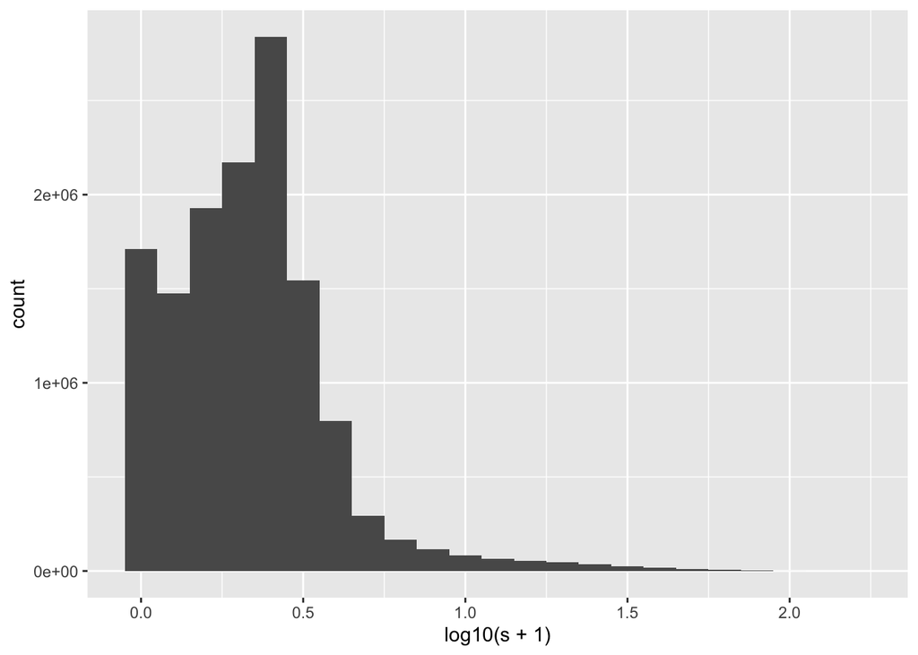

```r
data.frame(s = score(ba)) %>%
  ggplot(aes(x = log10(s + 1))) +
  geom_histogram(binwidth = 0.1)
```

This is an expected distribution: most of the data is background. Less than 5% of the reads for most any ChIP-seq dataset should be found within truly enriched regions.

Our data is now theoretically viewable on a genome browser.

# Exporting Genomic Ranges in .wig and .bigWig format

Wiggle files are fairly primitive: the actual data is a long vector corresponding to the ‘score’ column in our `ba` GRanges object. At the head of each chromosome, there is text that will look like this:

```
fixedStep chrom=chr2L start=1 step=10 span=10
```

that states what chromosome we’re on, where the sequence begins, and what the step and span are. (span == step for tiles. span != step for sliding windows).

BigWig files are essentially binarized versions of wig files, and so they take up less space. We can export either format using the `rtracklayer` function. However, **you should know whether you hope to display a .wig file on UCSC. If so, you need to append a track line to the wiggle file.** I will first demonstrate how to export.

### basic exporting and importing of .wig or .bw files

If you want to throw your data onto IGV, do `bw`. Wig files are better for UCSC if you just want to see how your data looks. If you want to make your data accessible on UCSC over the internet (send a link to a collaborator to browse your data), then you need to use `bw` and somehow make the bigWig file available on a server. (UCSC only reads bigWig files through URLs.) If any of you are interested in doing this, I can share a cheap and easy way to do this using github.

Below, I use dummy file paths to export our object `ba` from above in either the wiggle or bigWig format.

```r
# exporting a .wig file (no trackline)
rtracklayer::export(
  con = "path/to/save/to/my.wiggle.file.wig",
  object = ba,
  format = 'wig')

# exporting a .bigWig file
rtracklayer::export(
  con = "path/to/save/to/my.bigwig.file.bw",
  object = ba,
  format = 'bw')
```

**Note, it is necessary that all widths of your binned genome GRanges are equal. If they are not, at least the export .wig function will fail with an error.**

If you have a .wig or .bw file saved, you can import it as a Genomic Ranges object using:

```r
# example shown for bigWig, but change "format" appropriately for wig files...
my.data = rtracklayer::import(
  file = "path/to/save/to/my.bigwig.file",
  format = 'bw'
  )
```

And this would assign to `my.data` the imported file as a GRanges object.

However, for display of wig files on UCSC, we need a track line. You have three options:

1. Save the wig file as above, open it in a text editor and manually add a track line.
2. Save a track line to a text file, save the wig file as above *to the same file as the track line text file* using the option `append = TRUE`.
3. Use the helpful function that follows to do it all in one go.

### The Blythe Lab `wiggler` function:

If you are going to be making lots of wiggles to put up on UCSC, the following function might make your life a lot easier. It uses a function in `rtracklayer` to compose a trackline, saves it to a file, and then appends the .wig formatted data. The options to the function are the critical components of the track line:

`name` = a short name that describes the track

`description` = a longer name that can contain more information than the ‘name’

`color` = the color you want your data to be (use R color names here)

`smoothing` = the pixel smoothing you would like to apply. I do not recommend greater than 2

`y.axis.range` = the y-axis range. 0-20 is good for our data. For your data, this may be different

`height` = the track height. 50 is a good height for UCSC on most computer screens.

Please see the .wig track line documentation at https://genome.ucsc.edu/goldenPath/help/wiggle.html for more options and better descriptions of these options.

```r
wiggler = function(coverage.data, file, name = "short name", description = "description", color = 'forestgreen', smoothing = 2, y.axis.range = c(0,20), height = 50)
{
    # this function will take coverage data, like that produced by `binnedAverage()` and turn it into a viewable track for display on the UCSC genome browser. Necessary input is the coverage data (make sure that all widths are equal), and the output filepath. Tracklines will be generated with default values unless they are overwritten.
    require(rtracklayer)

    trackline = new('GraphTrackLine',
        name = name,
        description = description,
        alwaysZero = TRUE,
        type = 'wig',
        color = col2rgb(color)[,1],
        smoothingWindow = smoothing,
        windowingFunction = 'mean',
        viewLimits = y.axis.range,
        graphType = 'bar',
        autoScale = FALSE,
        visibility = 'full',
        maxHeightPixels = as(c(10, height, 100), 'integer')
        )

    write(x = as(trackline, "character"), file = file)

    export(object = coverage.data, con = file, format = 'wig', append = TRUE)
}
```

### exporting for viewing on UCSC:

We can now export the object we calculated above, `ba`, as a .wig file and upload to UCSC.

```r
wiggler(
  coverage.data = ba,
  file = "~/Desktop/test.wiggle.txt",
  name = "K27me3",
  description = "R_for_biologists_wig_test",
  color = "goldenrod4",
  smoothing = 2,
  y.axis.range = c(0,20),
  height = 50
  )
```

Now, navigate to https://genome.ucsc.edu/cgi-bin/hgGateway , click on the picture of the fruit fly, select dm6 from the drop-down menu, and click “Go”.

You should see a genome browser window. Click on “My Data” in the blue ribbon menu, and select “Custom Tracks”. In the new page, click the grey “add custom tracks” button. Click ’choose file" and find the file you just saved above. After it uploads, you should see information in the “Name” and “Description” column that looks familiar to you based on how you set up your trackline.

Click Go. Browse around. Some genes to look up (and then zoom out from) with good stuff are:

- *Ubx* (3’ end of the bithorax Hox cluster)
- *eve* (patterning gene that is polycomb methylated)
- *en* (another patterning gene that is polycomb methylated)

Zoom way out. Zoom in on something interesting. Try viewing the entire chromosome in one shot.

If this were *your* data, you would want to spend a lot of time at this step, and really get to know what you’ve measured, and begin developing some intuition about what the data tells you.

# Activities/Exercises:

## 1) View the region with the highest score in the test data.

Above, we used the function `range` to view the range of scores in the binned average data. * Using logical indexing, find the 10 bp bin to which the maximum score belongs. There is a function, `max`, that will report the maximum value.

- Using the function `GenomicRanges::resize`, widen this range to 10,000 bp centered over the maximum score 10 bp bin.
- Use `paste0` to construct a character string with the format “chromosome:start-end” corresponding to the 10,000 bp region surrounding the maximum score 10 bp bin.
- Copy and paste this character string into the UCSC search bar and observe. Where is this region? Does the maximum signal look ‘real’? What is the nearest gene annotation?

## 2) Calculate a binned average for one of *your* datasets.

Keep in mind that you may not want to calculate this using 10 bp windows. You may want to start with 100 bp, especially on your tiny laptops.

Show us your data!

## 3) Write a function that takes as input a .bam file and automatically performs all the steps in this demonstration.

We don’t type all this stuff out each time. We have functions that allow repetitive tasks to be performed with a single command, perhaps while looping over replicates. Think about what optional information you need to provide to the function, and what values never change. Customize it for your application.

# Bonus: Making publication quality plots using `Gviz`: shortcut/overview.

Screenshots from UCSC are great for lab meeting but lousy for publications. One package that makes nice coverage plots from your data is `Gviz`. It is clunky, and the manual is dozens of pages long, but this is perhaps a good time to introduce the package and get you started on making sharp plots for your presentations. Note, this is a quick introduction and is not intended to be a thorough treatment of this complex package.

First, procure `Gviz` from `Bioconductor`. (`BiocManager::install("Gviz")`).

```r
library(Gviz)
```

I have previously published a paper where we provided code for generating many of the published figures. (https://github.com/sblythe/Patternless_ATAC). In the analysis markdown, I have made a function that uses `Gviz` to generate nice coverage plots. I present it below in modified form to demonstrate what this package can do.

This function is meant to take a region of interest (in the format “chromosome:start-end”) (input option `ROI`) that you would want to plot after spending some time on the UCSC genome browser. It processes this input string to extract the chromosome locations and the start and stop. These are made into a Genomic Ranges object.

Because we usually don’t want the plot to be just the region of interest, but instead we want to have quite a bit of flanking region, we widen the region of interest by some amount (input option `view.width`). Sometimes you want to nudge the whole thing to the right or the left by a kb or more, so that functionality is built in as well (input option = `shifter`).

`Gviz` has many functions for making ‘tracks’ like the ones we see in the UCSC genome browser. In this function, we use the `Gviz` function `GeneRegionTrack` to get transcriptome assembly information from the `TxDb...` object corresponding to the data (*D.melanogater* dm6) around the region of interest.

We use the `Gviz` function `GenomeAxisTrack` to plot a 1 kb scale bar.

We use the `Gviz` function `DataTrack` to plot the coverage (input option `counts`) over this region of interest.

To actually plot the image, we finally use the `Gviz` function `plotTracks` to assemble the independent tracks we’ve defined above and put them together.

Additional input options control the y-axis label (`countname`), as well as the character string that appears in the title of the plot (`title`). The y-limits of the plot are set with the `ylims` option.

```r
gvizzer = function(ROI, view.width = 1e+4, counts = ba, countname = 'name', ylims = c(0,20), title = "test", shifter = 0){
  chr = substring(ROI,1,(regexpr(':',ROI)-1))
  ofrom = as.numeric(substring(ROI,(regexpr(':',ROI)+1),(regexpr('-',ROI)-1)))
  oto = as.numeric(substring(ROI,(regexpr('-',ROI)+1),nchar(ROI)))

  oregion = GRanges(chr, IRanges(ofrom, oto))
  region = resize(oregion, width = view.width, fix = 'center')
  start(region) = start(region) + shifter
  end(region) = end(region) + shifter

  from = as.numeric(start(region))
  to = as.numeric(end(region))

  title = paste0(title, ': ',ROI)

  grtrack = GeneRegionTrack(
    TxDb.Dmelanogaster.UCSC.dm6.ensGene::TxDb.Dmelanogaster.UCSC.dm6.ensGene,
    genome = 'dm6',
    from = from,
    to = to,
    chromosome = chr,
    stacking = 'squish'
    )

  gtr = GenomeAxisTrack(scale = 1000)

  trackcols = c('midnightblue')

  datatrack = DataTrack(
    counts,
    name = countname,
    type = 'polygon',
    col.mountain = trackcols[1],
    fill.mountain = rep(trackcols[1], 2)
    )

  plotTracks(
    trackList = list(gtr,datatrack, grtrack),
    from = from,
    to = to,
    chromosome = chr,
    main = title,
    ylim = ylims,
    cex.main = 1
    )
}
```

**Find a region of interest from the UCSC genome browser. If you click on the “chr:start-end” text at the top of the screen, a copyable text version of this appears in the search bar. Copy and paste that. This is the input to the function `gvizzer`**

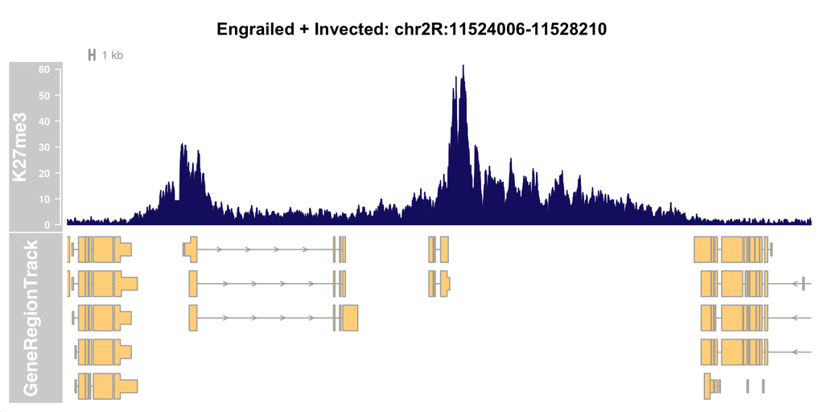

```r
# engrailed = chr2R:11524006-11528210

gvizzer(ROI = "chr2R:11524006-11528210", view.width = 150000, counts = ba, countname = "K27me3", ylims = c(0,60), title = "Engrailed + Invected")
```

Starting with this function, you can explore the manual for `Gviz` and begin generating your own publication quality images. You can certainly customize (or improve) this function to alter the way this plot looks.

I will say that if you have greater than one coverage track–as is usually the case–additional calls to `DataTrack` above can be made (perhaps with a for-loop or `sapply` function), and assembling the outputs in a `list` object. The order with which these files are listed in the call to `plotTracks` determines the order in the final plot.